# Fallstudie OCR und Sprachmodelle: Von Scans zu Tabellen

Texterkennung, Strukturierung und Klassifikation in vier Schritten

Simon Munzert, Hertie School

Modul 2, Session 7

# Die Aufgabe

Im Bürgerservice einer Stadt gehen täglich Schreiben ein: Beschwerden über Schlaglöcher, Lärm, nicht geleerte Tonnen, hin und wieder ein Lob. Viele kommen als Brief, Fax oder Foto. Bevor jemand sie bearbeiten kann, muss jemand sie lesen, dem richtigen Amt zuordnen und die Kerndaten erfassen: Wer schreibt, worum geht es, wo, wie dringend.

Wir bauen das als **Pipeline** nach: Scan → Text (OCR) → Kerndaten (Sprachmodell) → Kategorie (Sprachmodell) → Tabelle. Jeder Schritt schreibt sein Ergebnis in einen eigenen Ordner.

**Was Ihr braucht:** R mit `tidyverse`, `tesseract`, `pdftools`, `magick` und `ellmer`. Für die Schritte 3 und 4 ein Sprachmodell: Standard ist ein lokal laufendes Open-Source-Modell über [Ollama](https://ollama.com) (ohne Schlüssel, die Daten bleiben auf dem Rechner), alternativ ein Cloud-Anbieter mit API-Schlüssel. Installation im README. Das vollständige Skript liegt als `praxis-2-ocr-llm.R` daneben.

```r
source("R/pipeline.R")   # lädt die Pakete und die Funktionen der Pipeline
```

# Schritt 1: Die Scans ansehen

Vor dem Code kommt der Blick in den Ordner. Zehn erfundene Schreiben an die Stadt Musterstadt, erzeugt mit `erzeuge_rohdaten.R`: verschiedene Schriften (auch eine „Handschrift“), Formate (PNG, JPG, PDF), schief gescannt, verrauscht. Zwei davon sind absichtlich in schlechter Qualität: ein Fax und ein Handyfoto.

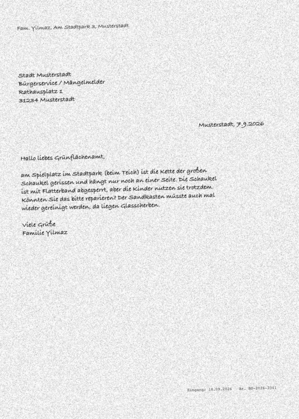

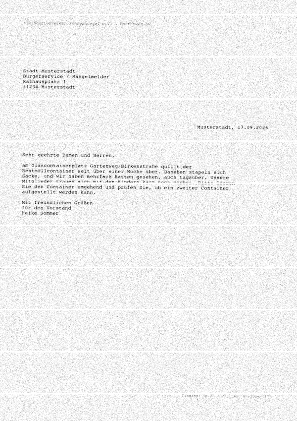

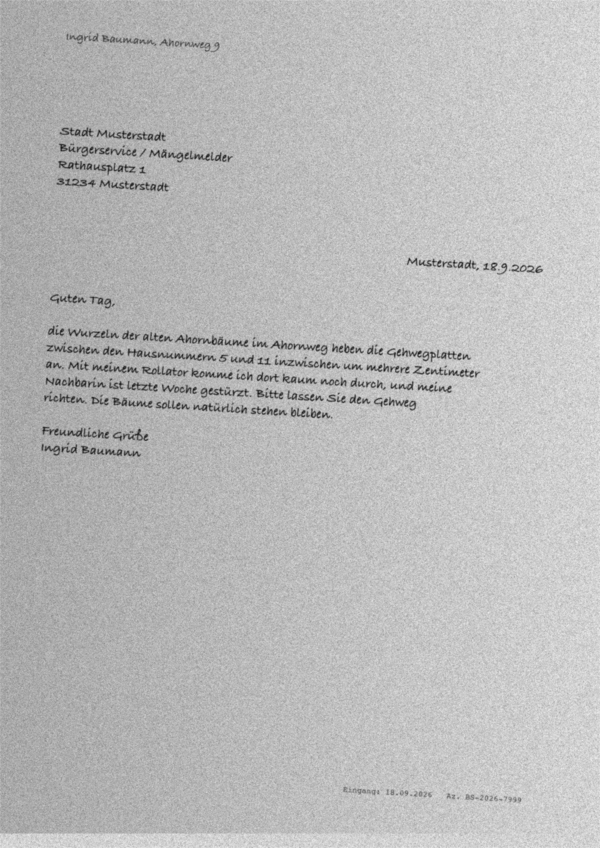

Von links: A02, ein gescannter Brief (leicht gedreht, verrauscht); A09, ein Fax (grob aufgelöst, Übertragungsstreifen); A10, ein Handyfoto (schief, unscharf, ungleichmäßig belichtet).

Dazu ein **Manifest** `dokumente.csv`: eine Zeile pro Dokument mit Dateiname und den Angaben, die wir am Ende als richtig ansehen (Goldstandard).

```r
manifest <- read_csv("daten/01_rohdaten/dokumente.csv", show_col_types = FALSE)
manifest |> select(id, datei, absender, datum, kategorie, dringlichkeit) |> knitr::kable()
```

| id | datei | absender | datum | kategorie | dringlichkeit |
| --- | --- | --- | --- | --- | --- |
| A01 | A01_anliegen.png | Renate Vogel | 03.09.2026 | Straßen und Verkehr | hoch |
| A02 | A02_anliegen.jpg | Familie Yilmaz | 7.9.2026 | Grünflächen und Spielplätze | mittel |
| A03 | A03_anliegen.pdf | Dr. Hartmut Krüger | 2026-09-09 | Abfall und Sauberkeit | niedrig |
| A04 | A04_anliegen.png | Sabine Oswald | 11.09.2026 | Beleuchtung | mittel |
| A05 | A05_anliegen.jpg | Jonas Petersen | 12. September 2026 | Lärm | hoch |
| A06 | A06_anliegen.png | Gisela und Werner Brandt | 14.09.26 | Straßen und Verkehr | mittel |
| A07 | A07_anliegen.jpg | Nguyen Thi Mai | 15.09.2026 | Abfall und Sauberkeit | hoch |
| A08 | A08_anliegen.pdf | Peter Lindqvist | 16.09.2026 | Sonstiges | niedrig |
| A09 | A09_anliegen.png | Kleingartenverein Sonnenhügel e.V. | 17.09.2026 | Abfall und Sauberkeit | hoch |
| A10 | A10_anliegen.jpg | Ingrid Baumann | 18.9.2026 | Straßen und Verkehr | mittel |

**Merke:** Ein Manifest sagt, was im Ordner liegt, woher es kommt und was man darüber weiß. Ohne Manifest ist ein Ordner mit 400 Scans nur ein Ordner mit 400 Scans.

# Schritt 2: OCR

Tesseract ist eine frei verfügbare Texterkennung (Optical Character Recognition), die lokal läuft. Alternativen sind Cloud-Dienste (Azure, Google, AWS) oder multimodale Sprachmodelle, die Bilder direkt lesen: meist besser bei Handschrift, dafür verlassen die Dokumente das Haus.

Vorher wird das Bild in Graustufen umgewandelt, von Flecken befreit und in Schwarz-Weiß gebracht. Bei verrauschten Scans macht das den Unterschied:

```r
ohne <- ocr_dokument("daten/01_rohdaten/A02_anliegen.jpg", vorverarbeitung = FALSE)
mit  <- ocr_dokument("daten/01_rohdaten/A02_anliegen.jpg", vorverarbeitung = TRUE)
original <- read_csv("daten/01_rohdaten/originaltexte.csv", show_col_types = FALSE)

tibble(variante = c("ohne Vorverarbeitung", "mit Vorverarbeitung"),
       worttrefferquote = c(worttrefferquote(ohne, original$text[2]),
                            worttrefferquote(mit, original$text[2]))) |>
  knitr::kable(digits = 2)
```

| variante | worttrefferquote |
| --- | --- |
| ohne Vorverarbeitung | 0.60 |
| mit Vorverarbeitung | 0.93 |

Jetzt alle zehn Dokumente. `schritt_ocr()` schreibt pro Dokument eine Textdatei und eine Sammeltabelle nach `daten/02_ocr/`. Liegt die Tabelle schon vor, wird sie geladen statt neu berechnet.

```r
ocr <- schritt_ocr(manifest)

ocr |>
  left_join(original, by = "id") |>
  mutate(worttrefferquote = map2_dbl(ocr_text, text, worttrefferquote)) |>
  select(id, datei, ocr_zeichen, worttrefferquote) |>
  knitr::kable(digits = 2)
```

| id | datei | ocr_zeichen | worttrefferquote |
| --- | --- | --- | --- |
| A01 | A01_anliegen.png | 546 | 1.00 |
| A02 | A02_anliegen.jpg | 550 | 0.93 |
| A03 | A03_anliegen.pdf | 568 | 1.00 |
| A04 | A04_anliegen.png | 430 | 1.00 |
| A05 | A05_anliegen.jpg | 616 | 1.00 |
| A06 | A06_anliegen.png | 587 | 1.00 |
| A07 | A07_anliegen.jpg | 438 | 0.97 |
| A08 | A08_anliegen.pdf | 613 | 0.96 |
| A09 | A09_anliegen.png | 586 | 0.50 |
| A10 | A10_anliegen.jpg | 244 | 0.28 |

Die Trefferquote sagt, wie viele Wörter des Originals im OCR-Text wiedergefunden werden. Die gescannten Briefe liegen über 90 %, das Fax bei der Hälfte, das Handyfoto darunter. So sieht das Ergebnis für das Foto aus:

```r
cat(ocr$ocr_text[ocr$id == "A10"])
```

```
## ee nn N Musterstadt, 18.9.2026
## 5 Ale Wurzeln der alten Ahornba me im Anornweg heben die Gehwegpiatten
## en ann nn a ee Zehti
## 2, Nachbarin ict Letzte ® Woche gestürzt. Bitte Lassen Sie den. Gen
## een 4 e u Er EN Ringangs 18.09.9036 BZ. 85-2026. 7339
```

Die Trefferquote sagt aber nicht, ob der gefundene Text stimmt. Auch in den gut lesbaren Dokumenten stecken Fehler, die keine Trefferquote anzeigt. Drei Zeilen aus den OCR-Texten von A07 und A08, daneben das, was im Scan steht:

```r
zeilen <- function(id, muster) ocr$ocr_text[ocr$id == id] |> str_split("\\n") |> pluck(1) |> str_subset(muster) |> head(1)
tibble(ocr_text = c(zeilen("A07", "Rosenallee \\d"), zeilen("A07", "wolle"), zeilen("A08", "Lind")),
       im_scan  = c("Mai Nguyen, Rosenallee 18", "… alte Farbeimer und Dämmwolle abgeladen …", "Peter Lindqvist · Kirchplatz 1 · 31234 Musterstadt")) |>
  knitr::kable()
```

| ocr_text | im_scan |
| --- | --- |
| Mai Nguyen, Rosenallee 12 | Mai Nguyen, Rosenallee 18 |
| voll Bauschutt, alte Farbeimer und Pämmwolle abgeladen. Es stinkt nach | … alte Farbeimer und Dämmwolle abgeladen … |
| Peter Lindgvist - Kirchplatz ı - 31234 Musterstadt | Peter Lindqvist · Kirchplatz 1 · 31234 Musterstadt |

Aus „Rosenallee 18“ wird „Rosenallee 12“: eine Hausnummer, die richtig aussieht und falsch ist. „Pämmwolle“ und „Lindgvist“ fallen wenigstens auf.

**Merke:** OCR liefert Text; Daten werden daraus erst im nächsten Schritt. Ein unlesbarer Scan fällt sofort auf, eine falsch gelesene Hausnummer bleibt unbemerkt. Beides muss die Pipeline abfangen.

# Schritt 3: Bereinigen und strukturieren

Man kann einem Sprachmodell den OCR-Text geben und sagen: „Mach mir daraus eine Tabelle.“ Das funktioniert, aber jedes Mal etwas anders: mal JSON, mal eine Aufzählung, mal fehlt ein Feld. Für ein Protokoll reicht das. Eine Datenbank braucht jedes Mal dieselben Felder.

Die Lösung ist eine **feste Antwortstruktur**: Wir geben dem Modell die Felder und ihre Typen vor, und es muss genau diese liefern. In `R/pipeline.R` ist das so definiert:

```r
typ_struktur <- type_object(
  "Kerndaten eines Bürgerschreibens",
  absender        = type_string("Name der absendenden Person(en), wie im Schreiben"),
  datum_iso       = type_string("Datum des Schreibens im Format JJJJ-MM-TT; leer, wenn nicht erkennbar"),
  betroffener_ort = type_string("Ort oder Adresse, auf die sich das Anliegen bezieht"),
  zusammenfassung = type_string("Das Anliegen in einem Satz, maximal 25 Wörter"),
  # ...
)
```

Jede Feldbeschreibung ist Teil des Prompts. Je präziser sie ist („Format JJJJ-MM-TT“, „leer, wenn nicht erkennbar“), desto weniger Nacharbeit.

Das Paket `ellmer` bietet für alle gängigen Anbieter dieselbe Schnittstelle. Der Anbieter ist eine Einstellung; ein Schlüssel käme aus der Umgebungsvariable und bleibt aus dem Code heraus.

```r
ANBIETER <- "ollama"   # lokal; oder "anthropic", "openai", "gemini" mit Schlüssel
llm_ok <- llm_schluessel_vorhanden(ANBIETER)
chat <- if (llm_ok) erzeuge_chat(ANBIETER, system_prompt = system_prompt_verwaltung) else NULL
cat("Sprachmodell verfügbar:", llm_ok, "\n")
```

```
## Sprachmodell verfügbar: TRUE
```

Zuerst korrigiert das Modell die OCR-Fehler und sagt, wie sicher es sich ist. Dann extrahiert es aus dem bereinigten Text die Felder. Beides landet in `daten/03_strukturiert/`.

```r
strukturiert <- schritt_strukturieren(ocr, chat)

strukturiert |>
  select(id, ocr_qualitaet, absender, datum_iso, betroffener_ort, zusammenfassung) |>
  knitr::kable()
```

| id | ocr_qualitaet | absender | datum_iso | betroffener_ort | zusammenfassung |
| --- | --- | --- | --- | --- | --- |
| A01 | gut | Renate Vogel, Lindenstraße 14, 31234 Musterstadt | 2026-09-03 | Lindenstraße 14, Musterstadt | Schlagloch vor Haus (ca. 40 cm breit) – Verletzung eines Radfahrers – Bitte um Ausbesserung |
| A02 | mittel | Fam. Yılmaz, Am Stadtpark 3, Musterstadt | 2026-09-07 | Spielplatz im Stadtpark (beim Teich) | Schaukelkette gerissen, Schaukel abgesperrt, Sandkasten mit Glasscherben. |
| A03 | gut | Dr. Hartmut Krüger, Bereweg 22, 31234 Musterstadt | 2026-09-09 | Bergweg 20-26, 31234 Musterstadt | Nicht abgeholte Papiertonnen (blaue Tonnen) am Bergweg 20-26. Laut Abfuhrkalender hätten sie am 8. September geleert werden sollen. Sie stehen seitdem am Straßenrand. |
| A04 | gut | Sabine Oswald, Mühlenweg 7, 31234 Musterstadt | NA | Mühlenweg 7, Musterstadt | Defekte Straßenlaterne (dunkel) und flackernde Straßenlaterne, Probleme mit der Beleuchtung des Gehweges. |
| A05 | gut | Jonas Petersen | 2026-09-12 | Hafenstraße 41, 31234 Musterstadt | Lärmbelästigung durch Gaststätte Zum Anker an Freitagen und Samstagen bis 2 Uhr nachts. Mehrfache Bitten an den Betreiber erfolglos. Anrufung der Polizei am letzten Samstag um 1:40 Uhr. |
| A06 | mittel | G.u. W. Brandt, Feldstraße 2a, 31234 Musterstadt | 2026-09-14 | Kreuzung Feldstraße/Bahnhofstraße, Musterstadt | Meldung eines fehlenden Stoppschilds (umgeknickt im Gebüsch) und Anregung zur Einrichtung eines Zebrastreifens. Die Anregung für einen Zebrastreifen wurde bereits 2024 geäußert. |
| A07 | gut | Mai Nguyen, Rosenallee 12, 31234 Musterstadt | 2026-09-15 | Ecke Rosenallee/Parkweg, Musterstadt | Meldung über illegale Ablagerung von Bauschutt, Farbeimern und Pammebollwolle, verbunden mit Geruchsbelästigung und möglicher Gefährdung von Schülern. Der Absender bietet Fotos als Beweismittel an. |
| A08 | gut | Peter Lindgvist | 2026-09-16 | Musterstadt | Dank für freundliche und schnelle Hilfe bei der Ummeldung des Wohnsitzes sowie Anregung zur Verbesserung der Information über die Öffnungszeiten auf der Webseite |
| A09 | schlecht | EOS nu ea wills Dean, BR23M Husemestadt | unsicher (vermutlich 37.09.2026, scheint aber ein Fehler zu sein) | Musterstadt | Meldung einer überfüllten Restmüllcontainer und Rattenbefall. Bitte um umgehende Entleerung und Prüfung der Aufstellung eines zweiten Containers. |
| A10 | schlecht | Ernang, 18.09.2026, BZ. 85-2026, 7339 | 2026-09-18 | Anornweg | Beschädigung von Gehwegplatten durch Wurzeln alter Ahornbaume. Ein Sturz einer Nachbarin wurde am … (unleserlich) vermerkt. *(Weitere Details im Text unleserlich)* |

```r
strukturiert |>
  filter(!is.na(unsichere_stellen), !str_to_lower(str_trim(unsichere_stellen)) %in% c("", "-", "keine")) |>
  mutate(unsichere_stellen = unsichere_stellen |> str_replace_all("\\s*\\n\\s*", " ") |> str_trunc(160)) |>
  select(id, ocr_qualitaet, unsichere_stellen) |>
  knitr::kable()
```

| id | ocr_qualitaet | unsichere_stellen |
| --- | --- | --- |
| A02 | mittel | - ‘groben’ könnte auch ‘großen’ sein (Kontextabhängig). - ‘viele grübe’ sollte ‘viele Grüße’ heißen (ist offensichtlich ein OCR-Fehler). |
| A06 | mittel | - ‘G.u.’ könnte eine Abkürzung sein, Bedeutung unklar. - ‘j j’ und weitere ‘j .’ am Zeilenende sind vermutlich OCR-Fehler und stellen wahrscheinlich keine re… |
| A07 | gut | - ‘Pämmevolle’ wurde als ‘Pammebollwolle’ korrigiert. Hier könnte ein Tippfehler vorliegen, die genaue Bezeichnung ist unklar. |
| A10 | schlecht | Diverse Stellen aufgrund von OCR-Fehlern und Unleserlichkeit. Die fehlenden Informationen wurden mit ‘(unleserlich)’ gekennzeichnet. Es ist schwierig, den ge… |

Vier Beobachtungen. Erstens: „Rosenallee 12“ steht unverändert in der Adresse von A07, und „Lindgvist“ bleibt „Lindgvist“ (A08). Das Modell kann beides nicht korrigieren, es hat den Scan nie gesehen, und 12 ist genauso plausibel wie 18. Zweitens: Aus „Pämmwolle“ (A07) hat das Modell keine Dämmwolle gemacht, sondern ein neues Fantasiewort; das steht in der Zusammenfassung und wird immerhin als unsicher markiert. Drittens: Bei A04 fehlt das Datum (`datum_iso` leer), obwohl es im OCR-Text steht. Viertens: Bei Fax und Foto (A09, A10, `ocr_qualitaet` „schlecht“) füllt das Modell die Felder trotzdem, mit Bruchstücken aus dem Zeichensalat als Absender und mit einem Datum, das es selbst als unsicher bezeichnet. Die Markierung „schlecht“ ist deshalb das wichtigste Feld: Solche Fälle gehören komplett zur Nachprüfung.

**Merke:** Ein Sprachmodell korrigiert plausibel; ob richtig, weiß es selbst nur zum Teil. Und es füllt Felder auch dann, wenn der Text nichts hergibt. Was es als unsicher oder schlecht markiert, muss ein Mensch prüfen. Was es nicht markiert, kann trotzdem falsch sein.

# Schritt 4: Klassifizieren

Die Zuordnung zu einem Themenbereich ist eine Klassifikationsaufgabe. Früher brauchte man dafür Trainingsdaten, heute reicht oft eine Liste der erlaubten Werte und eine klare Beschreibung. Die Liste ist in der Pipeline fest vorgegeben; das Modell kann nicht „Verkehrssicherheit“ erfinden, wenn „Straßen und Verkehr“ gemeint ist.

```r
klassifiziert <- schritt_klassifizieren(strukturiert, chat)
klassifiziert |> knitr::kable()
```

| id | kategorie | dringlichkeit | tonfall | begruendung |
| --- | --- | --- | --- | --- |
| A01 | Straßen und Verkehr | hoch | sachlich | Das Schreiben beschreibt ein Schlagloch in der Fahrbahn und einen daraus resultierenden Unfall. Dies fällt eindeutig unter den Themenbereich ‘Straßen und Verkehr’. |
| A02 | Grünflächen und Spielplätze | hoch | sachlich | Das Schreiben betrifft einen Spielplatz (Schaukel, Sandkasten) und liegt somit eindeutig innerhalb des Themenbereichs ‘Grünflächen und Spielplätze’. |
| A03 | Abfall und Sauberkeit | mittel | dankbar | Das Schreiben bezieht sich auf die nicht erfolgte Leerung von Papiertonnen, was direkt unter den Themenbereich ‘Abfall und Sauberkeit’ fällt. |
| A04 | Beleuchtung | hoch | sachlich | Das Schreiben thematisiert eine defekte Straßenlaterne und mangelnde Beleuchtung eines Gehweges, was eindeutig dem Themenbereich ‘Beleuchtung’ zuzuordnen ist. Es werden konkrete Mängel an öffentlicher… |
| A05 | Lärm | mittel | dankbar | Das Schreiben beschreibt Ruhestörung durch eine Gaststätte, was direkt unter den Themenbereich ‘Lärm’ fällt. |
| A06 | Straßen und Verkehr | mittel | verärgert | Das Schreiben betrifft das Fehlen eines Stoppschilds und den Wunsch nach einem Zebrastreifen, beides Aspekte des Straßen- und Verkehrsangebots. |
| A07 | Abfall und Sauberkeit | hoch | sachlich | Das Schreiben beschreibt das illegale Abladen von Müll (Bauschutt, Farbeimer, Pammebollwolle) und Verschmutzung, was eindeutig dem Themenbereich ‘Abfall und Sauberkeit’ zuzuordnen ist. |
| A08 | Sonstiges | niedrig | dankbar | Das Schreiben enthält Lob für Mitarbeiterinnen der Verwaltung und eine Anregung bezüglich der Webseiten-Informationen. Diese Punkte fallen unter |
| A09 | Abfall und Sauberkeit | hoch | sachlich | Das Schreiben thematisiert einen überfüllten Restmüllcontainer, wildes Müllablagen und Rattenbefall, was eindeutig dem Themenbereich ‘Abfall und Sauberkeit’ zuzuordnen ist. |
| A10 | Grünflächen und Spielplätze | mittel | sachlich | Das Schreiben bezieht sich auf Wurzeln von Ahornbaumen und beschädigte Gehwegplatten, was eindeutig in den Bereich Grünflächen und Spielplätze fällt. Die Erwähnung eines Sturzes deutet auf einen mögli… |

Die Kategorien stehen mit einer kurzen Erklärung im Prompt (siehe `anweisung_klassifikation` in `R/pipeline.R`). Das hat einen messbaren Grund: Mit der bloßen Liste im Antwortschema hat dasselbe lokale Modell in einem ersten Versuch Straßenlaternen dem Straßenverkehr und Bauschutt der Beleuchtung zugeordnet. Die Beschreibung der Aufgabe gehört zum Daten-Input.

# Das Ergebnis

Am Ende steht eine Tabelle: eine Zeile pro Schreiben, mit allem, was die Pipeline erzeugt hat, und daneben der Goldstandard aus dem Manifest. Erst dieser Vergleich sagt, ob das Verfahren gut genug ist.

```r
final <- manifest |>
  select(id, datei, gold_kategorie = kategorie, gold_dringlichkeit = dringlichkeit) |>
  left_join(strukturiert |> select(-datei), by = "id") |>
  left_join(klassifiziert, by = "id")

final |>
  select(id, kategorie, gold_kategorie, dringlichkeit, gold_dringlichkeit) |>
  mutate(kategorie_ok = kategorie == gold_kategorie,
         dringlichkeit_ok = dringlichkeit == gold_dringlichkeit) |>
  knitr::kable()
```

| id | kategorie | gold_kategorie | dringlichkeit | gold_dringlichkeit | kategorie_ok | dringlichkeit_ok |
| --- | --- | --- | --- | --- | --- | --- |
| A01 | Straßen und Verkehr | Straßen und Verkehr | hoch | hoch | TRUE | TRUE |
| A02 | Grünflächen und Spielplätze | Grünflächen und Spielplätze | hoch | mittel | TRUE | FALSE |
| A03 | Abfall und Sauberkeit | Abfall und Sauberkeit | mittel | niedrig | TRUE | FALSE |
| A04 | Beleuchtung | Beleuchtung | hoch | mittel | TRUE | FALSE |
| A05 | Lärm | Lärm | mittel | hoch | TRUE | FALSE |
| A06 | Straßen und Verkehr | Straßen und Verkehr | mittel | mittel | TRUE | TRUE |
| A07 | Abfall und Sauberkeit | Abfall und Sauberkeit | hoch | hoch | TRUE | TRUE |
| A08 | Sonstiges | Sonstiges | niedrig | niedrig | TRUE | TRUE |
| A09 | Abfall und Sauberkeit | Abfall und Sauberkeit | hoch | hoch | TRUE | TRUE |
| A10 | Grünflächen und Spielplätze | Straßen und Verkehr | mittel | mittel | FALSE | TRUE |

```r
final |>
  summarize(n = n(),
            kategorie_korrekt = mean(kategorie == gold_kategorie),
            dringlichkeit_korrekt = mean(dringlichkeit == gold_dringlichkeit)) |>
  knitr::kable(digits = 2)
```

| n | kategorie_korrekt | dringlichkeit_korrekt |
| --- | --- | --- |
| 10 | 0.9 | 0.6 |

Die Themenbereiche stimmen bis auf einen Fall: Die Baumwurzeln, die den Gehweg anheben (A10), ordnet das Modell den Grünflächen zu, unser Goldstandard dem Straßenbau. Beides ist vertretbar. Bei der Dringlichkeit liegt das Modell öfter daneben, meist eine Stufe höher als wir.

**Merke:** Zehn Dokumente sind ein Rauchtest; eine Evaluation fängt bei ein paar hundert an. Für den Ernstfall braucht es von Hand kodierte Fälle aus dem eigenen Haus und eine Verständigung darüber, was „hoch dringlich“ in Musterstadt heißt. Wie man das sauber misst, zeigt die Übung zur Validierung.

# Die Ablage

So sieht der Ordner nach einem vollständigen Lauf aus:

```
praxis-ocr-llm/
├── praxis-2-ocr-llm.R          das Skript (alles in einem Durchlauf)
├── praxis-2-ocr-llm.Rmd        diese Fallstudie
├── erzeuge_rohdaten.R          erzeugt die Beispielscans (einmalig)
├── R/pipeline.R                die Funktionen
├── daten/
│   ├── 01_rohdaten/            Scans + dokumente.csv (Manifest, Goldstandard)
│   ├── 02_ocr/                 ein .txt je Dokument + ocr_texte.csv
│   ├── 03_strukturiert/        anliegen_strukturiert.csv
│   └── 04_klassifikation/      anliegen_klassifiziert.csv
└── output/
    ├── ocr_guete.csv
    ├── anliegen_final.csv
    └── auswertung.csv
```

# Was wir mitnehmen

- **Rohdaten werden nie verändert.** Alles, was die Pipeline erzeugt, liegt woanders, ein nummerierter Ordner pro Schritt.
- **Jeder Schritt ist für sich wiederholbar.** Ändert sich der Prompt in Schritt 4, muss die OCR nicht neu laufen.
- **Struktur vorgeben.** Feste Felder und erlaubte Werte machen aus Modellantworten Daten.
- **Prüfen gegen einen Goldstandard.** Ohne von Hand kodierte Fälle weiß niemand, ob die Pipeline gut genug ist.
- **CSV statt Excel.** Textdateien, die jedes Programm lesen kann, auch in zehn Jahren.

**Zum Weiterspielen:** Ändert die Beschreibung von `dringlichkeit` in `R/pipeline.R` und lasst Schritt 4 mit `force = TRUE` neu laufen. Legt ein eigenes, datenschutzrechtlich unkritisches Dokument in `daten/01_rohdaten/`, ergänzt es im Manifest und schickt es durch die Pipeline. Oder tauscht den Anbieter: Liefern zwei Modelle dieselbe Klassifikation?